# Camparando bases de datos

Este documento en Rmarkdown está pensado para comparar dos bases de datos de Airbnb y poder evaluar los métodos de scraping.

- DB1: Los datos de **Inside Airbnb** tienen 1735 anuncios en Gipuzkoa (data/listings_gipuzkoa.csv) seleccionados manualmente en QGIS para permitir seleccionar los que está ngeoposicionados en el mar y por tanto fuera del contorno de la provincia.
- DB2: Los datos extraídos de la **API de Airbnb** por mapa contienen 2033 anuncios en Gipuzkoa.

¿qué anuncios tienen en común? ¿cuales no?

# Estas son las bases de datos en el mapa

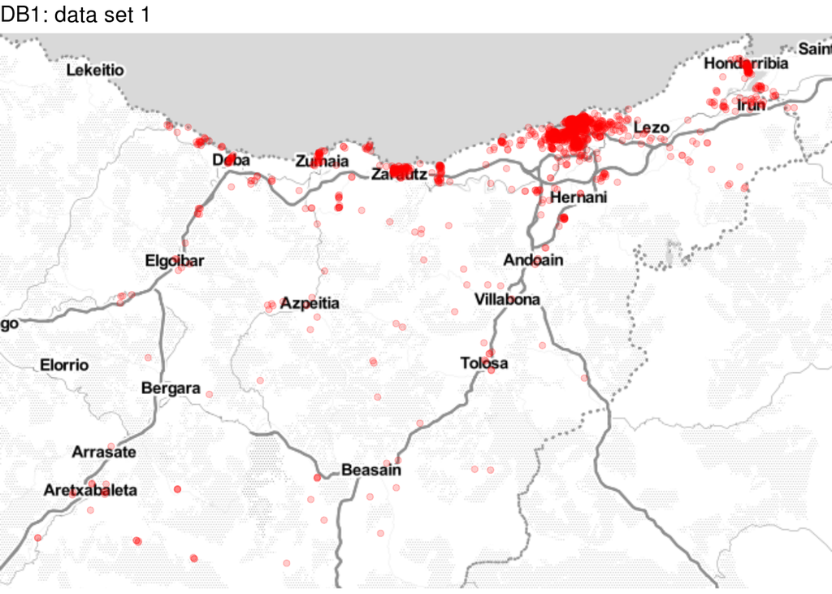

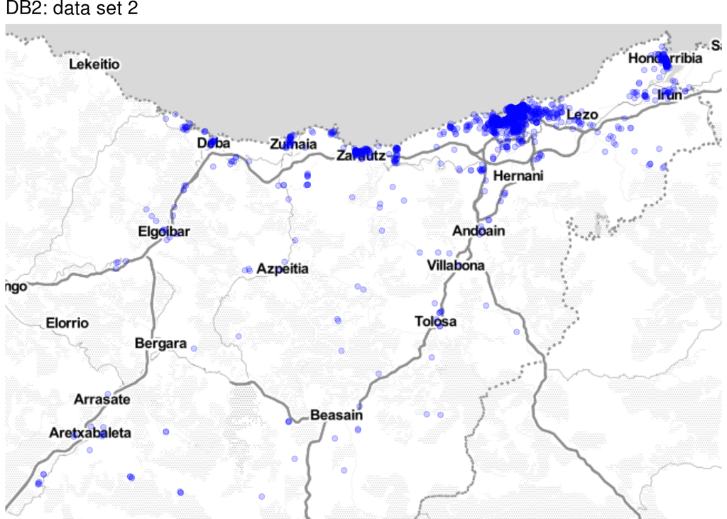

## Comparando datasets

DB1 tiene **1735** anuncios.

DB2 tiene **2033** anuncios.

A. DB1 y DB2 tienen **1310** anuncios comunes.

B. La DB1 tiene **425** anuncios que no están en la DB2.

C. La DB2 tiene **723** anuncios que no están en la DB1.

Hay, por tanto **2458** (A + B + C) anuncios diferentes en total. Que concuerda con 2458, que son el número de valores de id únicos entre DB1 y DB2.

```
## Using zoom = 10...
```

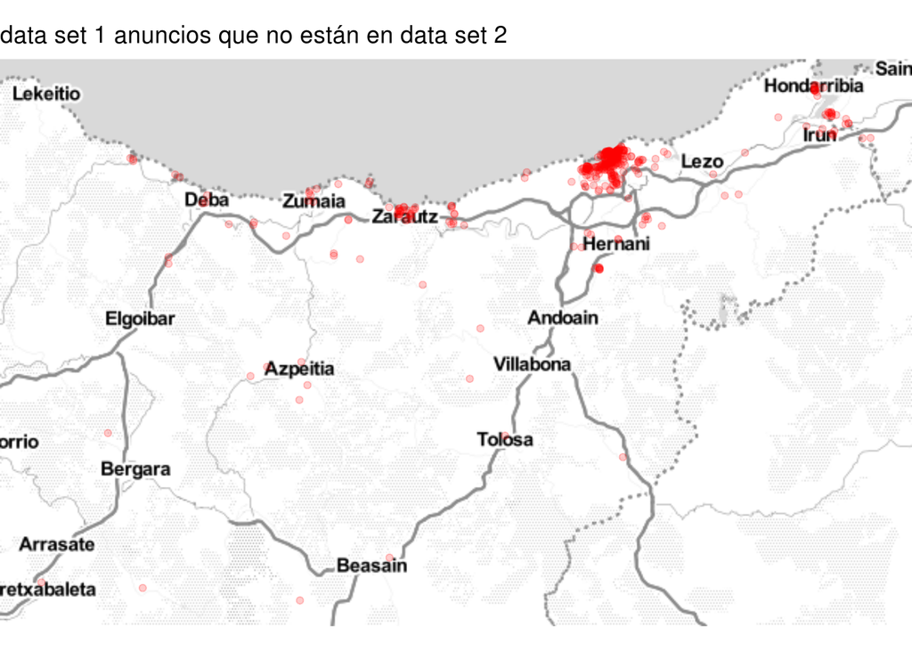

```
## Using zoom = 10...
```

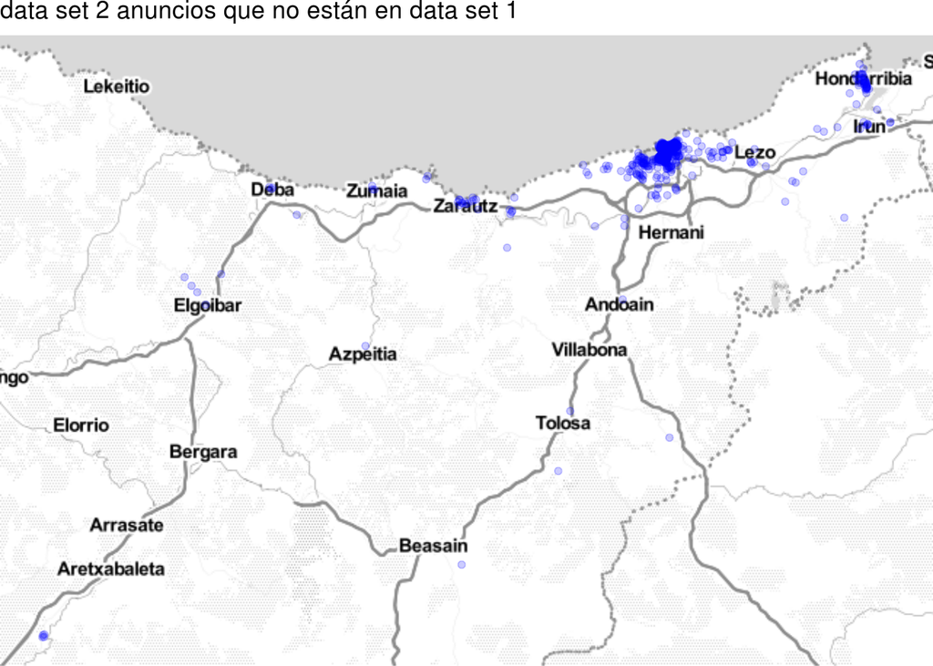

Estos son los anuncios que están en DB1 pero no en DB2:

```
## Currently generic markdown table using pandoc is not supported.
```

|  | id | name |
| --- | --- | --- |
| 4 | 17364613 | Casa rústica Zarautz San Sebastian |
| 16 | 15491948 | APARTAMENTO 2/3/4 PERSONAS EN CASA RURAL EKOIGOA |
| 17 | 17180130 | APARTAMENTO 4 PERSONAS EN CASA RURAL EKOIGOA |
| 18 | 5282487 | PRECIOSA CASA RURAL EN ALKIZA |
| 27 | 16791601 | Pequeño pueblo en entorno natural. |
| 33 | 16638914 | OTARDI LANDA ATERPETXEA (albergue Otardi) |
| 35 | 16525629 | Habitación encanto en Astigarraga |
| 39 | 14496955 | Habitación a 15 min de playa en bus |
| 40 | 17775467 | Piso a 10 min de San Sebastian |
| 44 | 9285134 | EXCELENTE HOSPEDAJE EN ASTIGARRAGA |
| 45 | 17845068 | Apartamento reformado |
| 46 | 17118572 | Bonito Duplex a 4km San Sebastián |
| 51 | 17280092 | Muy cerca de San Sebastian, Zumaia,Zarauz, Getaria |
| 54 | 4631401 | Private room in house with garden |
| 55 | 17692773 | Un remanso de paz y un deleite para los ojos. |
| 56 | 15873291 | GUARDILLA EN CASCO VIEJO AZPEITIA |
| 58 | 17699222 | ROMANTICO APARTAMENTO PROXIMO A SAN SEBASTIAN. |
| 63 | 17273149 | Argiñenea Casa Rural |
| 65 | 17492787 | Estudio boutique en pleno corazón del Pais Vasco |
| 68 | 17741355 | Apartamento zona rural ideal familia con 3 niños |
| 71 | 16801277 | Apartamento con vistas al monte y al mar ESS00593 |
| 72 | 17022812 | IKUSPEGI - Basque Stay |
| 75 | 17578224 | AGROTURISMO ERLETE GOIKOA |
| 76 | 17602259 | Piso 2habitaciones con garaje |
| 79 | 7394458 | Casa 2 plantas con encanto no.registro ESS00698 |
| 94 | 16685481 | BEATIFUL VIEW OF THE CITY |
| 95 | 17790556 | Lovely Light Double Room Near Beach |
| 97 | 12538218 | July and August flat in Amara |
| 107 | 13260368 | Nice room in the city center |
| 126 | 14156593 | Bonito apartamento en gros para dos |

[output cut: 395 more lines]

|  | ID | Room.Type |
| --- | --- | --- |
| 16 | 7832696 | private_room |
| 17 | 7796390 | private_room |
| 18 | 7832552 | private_room |
| 19 | 7796671 | private_room |
| 42 | 5957745 | private_room |
| 49 | 12807703 | private_room |
| 55 | 16403209 | entire_home |
| 57 | 9141976 | entire_home |
| 62 | 12241649 | private_room |
| 75 | 6615752 | entire_home |
| 79 | 12928028 | entire_home |
| 80 | 14074109 | entire_home |
| 83 | 10777814 | entire_home |
| 86 | 4517790 | entire_home |
| 87 | 12804021 | entire_home |
| 89 | 6937406 | entire_home |
| 95 | 10628546 | entire_home |
| 96 | 1015779 | entire_home |
| 97 | 10624453 | entire_home |
| 98 | 10627000 | entire_home |
| 101 | 12107288 | entire_home |
| 104 | 15051948 | entire_home |
| 108 | 9693630 | entire_home |
| 110 | 15839432 | entire_home |
| 112 | 12333795 | entire_home |
| 113 | 14232564 | entire_home |
| 118 | 15839419 | entire_home |
| 119 | 16431619 | entire_home |
| 120 | 603468 | entire_home |
| 121 | 4063517 | entire_home |

[output cut: 693 more lines]

## Datos

InsideAIrbnb + InsideAirbnb.com/euskadi + Fecha scraping: 2017-03-24 El subset de datos de Gipuzkoa se ha realizado con QGIS seleccionando los anuncios con herramienta de selección manual que estabn en el polígono de Gipuzkoa para poder incluir los que estaban ubicados en el mar.

API Airbnb + API + Fecha scraping: 2017-04-01